# Movie recommendation system

> Often, the question of different aspects of business including the reduction of customer attrition, expansion of market share, increment of sales, etcetera, are based on various approaches as adopted by the underlying business. Such approaches might include but not limited to, conducting marketing campaigns tailored for various market segments, adoption of current customer satisfaction practices, use of recommendation tools, etc.

> Primarily, recommender systems as observed by Shetty [1], help users discover new movieIds as well as services. This implies that, a recommender system ought to be configured such that they recommend the best movieId (that is, most relevant movieId based on user interactions). To this end, recommender systems are essential especially in today’s world where most of the goods and services are digitalized which often leads to users being overwhelmed by choice and need help finding what they're looking for. The ease of recommendation will often lead to more satisfied users and hence more sales. Uses of Recommender systems Some of the applications of recommender systems include, recommending movies, music, television programs, books, documents, websites, conferences, tourism scenic spots and learning materials.

#### Objective

> In practice, there are quite a number of recommender systems which are broadly categorized into traditional and modern recommender systems. In an article by Sciforce blog [2], it is noted that traditional recommender systems (RSs) include content-based and collaborative filtering (CF) systems grounding their recommendations on historical interactions and user/item attributes. Content-based recommendations are mainly drawn on the user’s item and profile features, and CF seeks a similar audience’s preferences. On the other hand, modern recommender systems are mainly based on deep learning techniques such as convolutional neural networks (CNNs) which [2] observes as being a good fit for unstructured multimedia data processing given effective feature extraction.

##### Research Objective

[figure not shown]

## Load Libraries

```python
from math import sqrt
import pandas as pd
import numpy as np
import seaborn as sns
from matplotlib import pyplot as plt
from sklearn.feature_extraction.text import TfidfVectorizer
from sklearn.metrics.pairwise import linear_kernel
from sklearn.model_selection import train_test_split
from pandas.api.types import CategoricalDtype
from scipy.sparse import  csr_matrix
import scipy.sparse as sparse
#Deep learning
import keras
import tensorflow as tf
import warnings
warnings.filterwarnings('ignore')
from keras.callbacks import EarlyStopping
from keras import backend as K
from keras.models import Sequential, Model
from keras.layers.core import Dense, Lambda, Activation
from keras.layers import Embedding, Input, Dense, Reshape, Flatten, merge
from tensorflow.keras.optimizers import RMSprop
from keras.regularizers import l2
from numpy import count_nonzero
from tableone import TableOne, load_dataset
from scipy import stats
from keras.utils.vis_utils import plot_model
from scipy.sparse import  csr_matrix
from keras.utils.vis_utils import plot_model
from sklearn.decomposition import NMF
```

# Dataset : Small Movielens

```python
# Reading ratings file
ratings = pd.read_csv('ratings.csv', sep=',', encoding='latin-1', usecols=['userId','movieId','rating','timestamp'])

# Reading movies file
movies = pd.read_csv('movies.csv', sep=',', encoding='latin-1', usecols=['movieId','title','genres'])
```

```python
df_movie = movies
df_ratings = ratings
```

```python
df_movies1 = df_movie.merge(df_ratings)[['genres', 'rating']]
```

#### Examine data sparsity

```python
users = list(np.sort(ratings.userId.unique())) # Get our unique customers
movies = list(ratings.movieId.unique()) # Get our unique products that were purchased
rating = list(ratings.rating) # All of our purchases
rows = ratings.userId.astype('category', users).cat.codes
# pull row indices
cols = ratings.movieId.astype('category', movies).cat.codes
# pull column indices
user_item = sparse.csr_matrix((rating, (rows, cols)), shape=(len(users), len(movies)))
matrix_size = user_item.shape[0]*user_item.shape[1] # Number of possible interactions in the matrix
num_purchases = len(user_item.nonzero()[0]) # Number of items interacted with
sparsity = 100*(1 - (1.0*num_purchases/matrix_size))
print(f'{round(sparsity,4)} % Sparsity')
```

```
98.3 % Sparsity
```

```python
print(num_purchases, 'interactions')
```

```
100836 interactions
```

```python
print(len(movies), 'Items')
```

```
9724 Items
```

```python
print(len(users), 'Users')
```

```
610 Users
```

### Exploratory Data Analysis(EDA)

```python
df_movie.head(5)
```

|  | movieId | title | genres |
| --- | --- | --- | --- |
| 0 | 1 | Toy Story (1995) | Adventure\|Animation\|Children\|Comedy\|Fantasy |
| 1 | 2 | Jumanji (1995) | Adventure\|Children\|Fantasy |
| 2 | 3 | Grumpier Old Men (1995) | Comedy\|Romance |
| 3 | 4 | Waiting to Exhale (1995) | Comedy\|Drama\|Romance |
| 4 | 5 | Father of the Bride Part II (1995) | Comedy |

[figure not shown]

```python
plt.figure(figsize=(20,7))
genrelist = df_movies1['genres'].apply(lambda genrelist_movie : str(genrelist_movie).split("|"))
genres_count = {}

for genrelist_movie in genrelist:
    for genre in genrelist_movie:
        if(genres_count.get(genre,False)):
            genres_count[genre]=genres_count[genre]+1
        else:
            genres_count[genre] = 1

genres_count.pop('(no genres listed)')
genres_count = {k: v for k, v in sorted(genres_count.items(), key=lambda item: item[1], reverse=True)}
plt.bar(genres_count.keys(),genres_count.values(),color='steelblue')
plt.title('Distribution of number of movies by genre')
plt.xlabel('Genre')
plt.ylabel('Number of movies')
plt.grid()
plt.show()
```

```python
df_ratings.head(5)
```

|  | userId | movieId | rating | timestamp |
| --- | --- | --- | --- | --- |
| 0 | 1 | 1 | 4.0 | 964982703 |
| 1 | 1 | 3 | 4.0 | 964981247 |
| 2 | 1 | 6 | 4.0 | 964982224 |
| 3 | 1 | 47 | 5.0 | 964983815 |
| 4 | 1 | 50 | 5.0 | 964982931 |

### Distribution of users rating

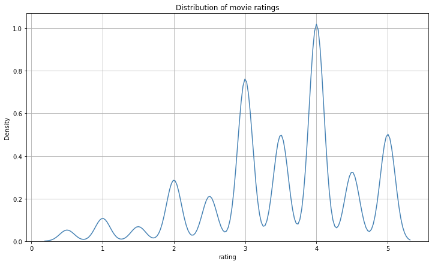

```python
plt.figure(figsize=(12,7))
sns.kdeplot(df_ratings["rating"], color = 'steelblue');
plt.title('Distribution of movie ratings')
plt.grid()
plt.show()
```

```python
print("Shape of the dataframes: \n"+ " Rating DataFrame: "+ str(df_ratings.shape)+"\n Movies DataFrame"+ str(df_movie.shape))
```

```
Shape of the dataframes:
 Rating DataFrame: (100836, 4)
 Movies DataFrame(9742, 3)
```

```python
combine_movie_ratings = pd.merge(df_movie, df_ratings, on='movieId', how='inner')
```

```python
combine_movie_ratings.head(2)
```

|  | movieId | title | genres | userId | rating | timestamp |
| --- | --- | --- | --- | --- | --- | --- |
| 0 | 1 | Toy Story (1995) | Adventure\|Animation\|Children\|Comedy\|Fantasy | 1 | 4.0 | 964982703 |
| 1 | 1 | Toy Story (1995) | Adventure\|Animation\|Children\|Comedy\|Fantasy | 5 | 4.0 | 847434962 |

```python
combine_movie_ratings = combine_movie_ratings.drop('timestamp', axis=1)
```

```python
combine_movie_ratings.shape
```

```
(100836, 5)
```

Grouping the rating based on user

```python
ratings_grouped_by_users = combine_movie_ratings.groupby('userId').agg([np.size, np.mean])
```

```python
ratings_grouped_by_users.head(2)
```

| userId | movieId size | movieId mean | rating size | rating mean |
| --- | --- | --- | --- | --- |
| 1 | 232 | 1854.603448 | 232.0 | 4.366379 |
| 2 | 29 | 70350.275862 | 29.0 | 3.948276 |

```python
ratings_grouped_by_users = ratings_grouped_by_users.drop('movieId', axis = 1)
```

### Top 10 users who have rated most of the movies

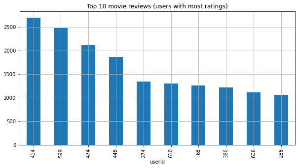

```python
ratings_grouped_by_users['rating']['size'].sort_values(ascending=False).head(10).plot(kind = 'bar', figsize = (10,5))
plt.title('Top 10 movie reviews (users with most ratings)')
plt.grid()
plt.show()
```

```python
ratings_movies = combine_movie_ratings.groupby('movieId').agg([np.mean], np.size)
```

```python
ratings_movies.shape
```

```
(9724, 2)
```

```python
ratings_movies.head(3)
```

| movieId | userId mean | rating mean |
| --- | --- | --- |
| 1 | 306.530233 | 3.920930 |
| 2 | 329.554545 | 3.431818 |
| 3 | 283.596154 | 3.259615 |

```python
ratings_movies = ratings_movies.drop('userId', axis=1)
```

### Movies with high average rating

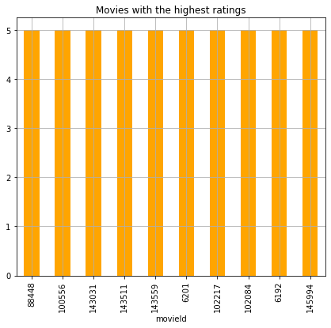

```python
ratings_movies['rating']['mean'].sort_values(ascending=False).head(10).plot(kind='bar',
                                                                                       figsize=(7,6), color = 'orange');
plt.title('Movies with the highest ratings')
plt.grid()
plt.show()
```

### Movies with low average rating

```python
least_rated_movies = ratings_movies['rating']['mean']< 1.5
```

```python
rated_low = ratings_movies[least_rated_movies]
```

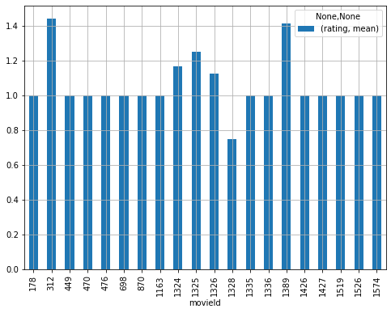

```python
rated_low.head(20).plot(kind='bar', figsize=(8,6));
plt.grid()
```

```python
rated_low.head(10)
```

| movieId | rating mean |
| --- | --- |
| 178 | 1.000000 |
| 312 | 1.444444 |
| 449 | 1.000000 |
| 470 | 1.000000 |
| 476 | 1.000000 |
| 698 | 1.000000 |
| 870 | 1.000000 |
| 1163 | 1.000000 |
| 1324 | 1.166667 |
| 1325 | 1.250000 |

```python
#Merge
df_movies = df_movie.merge(df_ratings)

groupby = ['genres']
nonnormal = ['movieId']

df_movies = df_movies[df_movies['genres'].isin(list(genres_count.keys())[0:5])]
```

```python
TestTable = TableOne(df_movies,columns = ['genres', 'rating'],
                   groupby=groupby, pval=True)
```

```python
TestTable
```

|  |  | Grouped by genres Missing | Grouped by genres Overall | Grouped by genres Action | Grouped by genres Adventure | Grouped by genres Comedy | Grouped by genres Drama | Grouped by genres Thriller | Grouped by genres P-Value |
| --- | --- | --- | --- | --- | --- | --- | --- | --- | --- |
| n |  |  | 14320 | 186 | 19 | 7196 | 6291 | 628 |  |
| rating, n (%) | 0.5 | 0 | 191 (1.3) | 4 (2.2) |  | 136 (1.9) | 44 (0.7) | 7 (1.1) | <0.001 |
|  | 1.0 |  | 486 (3.4) | 13 (7.0) | 1 (5.3) | 348 (4.8) | 99 (1.6) | 25 (4.0) |  |
|  | 1.5 |  | 324 (2.3) | 6 (3.2) | 1 (5.3) | 256 (3.6) | 49 (0.8) | 12 (1.9) |  |
|  | 2.0 |  | 1198 (8.4) | 31 (16.7) | 7 (36.8) | 828 (11.5) | 287 (4.6) | 45 (7.2) |  |
|  | 2.5 |  | 849 (5.9) | 13 (7.0) |  | 515 (7.2) | 295 (4.7) | 26 (4.1) |  |
|  | 3.0 |  | 2971 (20.7) | 51 (27.4) | 5 (26.3) | 1614 (22.4) | 1144 (18.2) | 157 (25.0) |  |
|  | 3.5 |  | 1778 (12.4) | 22 (11.8) | 2 (10.5) | 854 (11.9) | 830 (13.2) | 70 (11.1) |  |
|  | 4.0 |  | 3847 (26.9) | 27 (14.5) | 2 (10.5) | 1586 (22.0) | 2055 (32.7) | 177 (28.2) |  |
|  | 4.5 |  | 1044 (7.3) | 11 (5.9) |  | 403 (5.6) | 593 (9.4) | 37 (5.9) |  |
|  | 5.0 |  | 1632 (11.4) | 8 (4.3) | 1 (5.3) | 656 (9.1) | 895 (14.2) | 72 (11.5) |  |

[1] Chi-squared tests for the following variables may be invalid due to the low number of observations: rating.

```python
TestTable.to_excel('summary_10M.xlsx')
```

```python
TestTable = TableOne(df_movies,columns = ['genres', 'rating'],
                   groupby=groupby, categorical=['genres'], nonnormal=nonnormal, pval=True, tukey_test=True)

display(TestTable)

TestTable.to_excel('summary_10M_test.xlsx')
```

|  |  | Grouped by genres Missing | Grouped by genres Overall | Grouped by genres Action | Grouped by genres Adventure | Grouped by genres Comedy | Grouped by genres Drama | Grouped by genres Thriller | Grouped by genres P-Value |
| --- | --- | --- | --- | --- | --- | --- | --- | --- | --- |
| n |  |  | 14320 | 186 | 19 | 7196 | 6291 | 628 |  |
| genres, n (%) | Action | 0 | 186 (1.3) | 186 (100.0) |  |  |  |  | <0.001 |
|  | Adventure |  | 19 (0.1) |  | 19 (100.0) |  |  |  |  |
|  | Comedy |  | 7196 (50.3) |  |  | 7196 (100.0) |  |  |  |
|  | Drama |  | 6291 (43.9) |  |  |  | 6291 (100.0) |  |  |
|  | Thriller |  | 628 (4.4) |  |  |  |  | 628 (100.0) |  |
| rating, mean (SD) |  | 0 | 3.4 (1.1) | 2.9 (1.1) | 2.7 (1.0) | 3.2 (1.1) | 3.7 (0.9) | 3.4 (1.0) | <0.001 |

[1] Chi-squared tests for the following variables may be invalid due to the low number of observations: genres.

#### Data Preparation

> (1)- Merge the dataframes to obtain complete information regarding a user, a movie and the corresponding interaction.

> (2)- Split the data into test and train.

##### Merge the dataframes

```python
df_ratings.columns
```

```
Index(['userId', 'movieId', 'rating', 'timestamp'], dtype='object')
```

```python
df_movies.columns
```

```
Index(['movieId', 'title', 'genres', 'userId', 'rating', 'timestamp'], dtype='object')
```

```python
#Merge the dataframes
movie_ratings = df_movies.merge(df_ratings)
movie_ratings = movie_ratings
movie_ratings.head()
```

|  | movieId | title | genres | userId | rating | timestamp |
| --- | --- | --- | --- | --- | --- | --- |
| 0 | 5 | Father of the Bride Part II (1995) | Comedy | 6 | 5.0 | 845553938 |
| 1 | 5 | Father of the Bride Part II (1995) | Comedy | 31 | 3.0 | 850466642 |
| 2 | 5 | Father of the Bride Part II (1995) | Comedy | 43 | 5.0 | 848994281 |
| 3 | 5 | Father of the Bride Part II (1995) | Comedy | 45 | 3.0 | 959625102 |
| 4 | 5 | Father of the Bride Part II (1995) | Comedy | 58 | 4.0 | 847719151 |

##### Split the dataframes to test and train sets

```python
X = movie_ratings[['userId', 'movieId']].values
y = movie_ratings['rating'].values
X_train, X_test, y_train, y_test = train_test_split(X, y, test_size=0.3, random_state=42)
X_train.shape, X_test.shape, y_train.shape, y_test.shape
```

```
((10024, 2), (4296, 2), (10024,), (4296,))
```

#### Modeling

```python
X = movie_ratings[['userId', 'movieId']]
y = movie_ratings['rating']
X_train, X_test, y_train, y_test = train_test_split(X, y, test_size=0.3, random_state=42)
```

### Step 1. Define an index vector of all unique users and movies

```python
#Order the items and users
c_movie = CategoricalDtype(sorted(movie_ratings['movieId'].unique()), ordered=True)
c_user = CategoricalDtype(sorted(movie_ratings['userId'].unique()), ordered=True)
```

```python
print(len(c_movie.categories))
print(len(c_user.categories))
```

```
2150
586
```

```python
train, test = train_test_split(X, test_size=0.30, random_state=420)
print(train.shape)
print(test.shape)
```

```
(10024, 2)
(4296, 2)
```

```python
test = X_test.copy()
train = X_train.copy()

testw = test.copy()

testw['userId'] = test['userId'].astype(c_user)

testw['movieId'] = test['movieId'].astype(c_movie)

test_pred = testw.copy()
```

```python
testw.info()
```

```
<class 'pandas.core.frame.DataFrame'>
Int64Index: 4296 entries, 533 to 2015
Data columns (total 2 columns):
 #   Column   Non-Null Count  Dtype
---  ------   --------------  -----
 0   userId   4296 non-null   category
 1   movieId  4296 non-null   category
dtypes: category(2)
memory usage: 152.4 KB
```

### Step 2: Define a 1/0 binary sparse matrix of User-items for training set

```python
from scipy.sparse import  csr_matrix
train_df = csr_matrix((np.ones(len(train)), (train['userId'].astype('category').cat.codes,
                                               train['movieId'].astype('category').cat.codes)),
                  shape=( len(c_user.categories), len(c_movie.categories)))
print(f'{100*train_df.sum()/(train_df.shape[0]*train_df.shape[1])}% Sparsity')
```

[output not shown]

### Step 3. Run the model on the training set

Models were testing:

1. Simple Cosine Similarity on items
2. Non-negative matrix factorization
3. Simple Neural Collaborative Filtering

Evaluation:

- Recall: % of 1s in the Test set
- MPR: Mean Percentile Rank

#### Simple Cosine Similarity

Doing this in chunks for the test set so that we don't run into memory issues. For the recall measure, if the track's relative percentile is < 0.5 then its a 1

```python
# Simple Cosine Similarity
from scipy.stats import percentileofscore
def simple_cosine(data, pred):
    from sklearn.metrics.pairwise import cosine_similarity
    #Cosine similarity model to generate a matrix and determine the closest recommendation depending on the similarity matrix

    # normalize to obtain the % importance to user
    scaled_df = data.multiply(1/data.sum(axis=1)).tocsr()
    # implement cosine similarity
    sim = cosine_similarity(scaled_df.transpose(), dense_output=False)
    sim[np.diag_indices(sim.shape[0])] = 0
    denom = np.asarray(sim.sum(axis=1)).reshape(-1)

    # implement per chunk to handle memory issues
    user_index = pred['userId'].cat.codes.values
    item_index = pred['movieId'].cat.codes.values

    number_of_chunks = 30
    chunks = np.array_split(np.arange(scaled_df.shape[0]), number_of_chunks)
    res = []
    prev_max = 0
    for i,indexx in enumerate(chunks):
        print(f'Implementing chunk : {i+1}/{number_of_chunks}')
        score = (scaled_df[indexx].dot(sim)) / denom
        score = (-score).argsort() / denom.shape[0]
        sel = (user_index >= indexx.min()) & (user_index <= indexx.max())
        chunk_score = np.asarray(score[user_index[sel] - prev_max, item_index[sel]]).reshape(-1)
        res.append(chunk_score)
        prev_max = indexx.max() + 1
    return np.concatenate(res)


# Evaluate performance of the model
Recommendations = simple_cosine(train_df, testw)
mpr_cosine_sim = Recommendations.sum()/len(testw)
print(f'MPR: {mpr_cosine_sim:.5f}')
rec_cosine_sim = (Recommendations < 0.5).sum()/len(testw)
print(f'Model Recall rate: {rec_cosine_sim:.5f}')
```

```
Implementing chunk : 1/30
Implementing chunk : 2/30
Implementing chunk : 3/30
Implementing chunk : 4/30
Implementing chunk : 5/30
Implementing chunk : 6/30
Implementing chunk : 7/30
Implementing chunk : 8/30
Implementing chunk : 9/30
Implementing chunk : 10/30
Implementing chunk : 11/30
Implementing chunk : 12/30
Implementing chunk : 13/30
Implementing chunk : 14/30
Implementing chunk : 15/30
Implementing chunk : 16/30
Implementing chunk : 17/30
Implementing chunk : 18/30
Implementing chunk : 19/30
Implementing chunk : 20/30
Implementing chunk : 21/30
Implementing chunk : 22/30
Implementing chunk : 23/30
Implementing chunk : 24/30
Implementing chunk : 25/30
Implementing chunk : 26/30
Implementing chunk : 27/30
Implementing chunk : 28/30
Implementing chunk : 29/30
Implementing chunk : 30/30
MPR: 0.42323
Model Recall rate: 0.59451
```

#### Neural Collaborative Filtering

```python
# Create the Training Set
sample_size_with_no_interactions = int(len(train)*0.2)
n_users = c_user.categories.shape[0]
num_of_items = c_movie.categories.shape[0]
# Create Training Set
trnx_users = train['userId'].astype('category').cat.codes.values
trnx_items = train['movieId'].astype('category').cat.codes.values
train_labels = np.ones(len(trnx_users))
# insert negative samples
u = np.random.randint(n_users, size=sample_size_with_no_interactions)
i = np.random.randint(num_of_items, size=sample_size_with_no_interactions)
non_neg_indexx = np.where(train_df[u,i] == 0)
trnx_users = np.concatenate([trnx_users, u[non_neg_indexx[1]]])
trnx_items = np.concatenate([trnx_items, i[non_neg_indexx[1]]])
train_labels = np.concatenate([train_labels, np.zeros(u[non_neg_indexx[1]].shape[0])])
print((trnx_users.shape, trnx_items.shape, train_labels.shape))

# shuffle the data
X = np.stack([trnx_users, trnx_items, train_labels], axis=1)
np.random.shuffle(X)
```

```
((12014,), (12014,), (12014,))
```

```python
def neural_network_model(number_of_users, num_items, latent_dim, regs=[0,0]):
    # model vars
    user_input = Input(shape=(1,), dtype='int32', name = 'user_input')
    item_input = Input(shape=(1,), dtype='int32', name = 'item_input')

    MF_Embedding_User = Embedding(input_dim = number_of_users, output_dim = latent_dim, name = 'user_embedding',
                                  embeddings_regularizer = l2(regs[0]), input_length=1)
    MF_Embedding_Item = Embedding(input_dim = num_items, output_dim = latent_dim, name = 'item_embedding',
                                  embeddings_regularizer = l2(regs[1]), input_length=1)

    # essential to define an embedding vector!
    user_latent = Flatten()(MF_Embedding_User(user_input))
    item_latent = Flatten()(MF_Embedding_Item(item_input))

    # user-item embedding productper element
    predict_vector = merge.Multiply()([user_latent, item_latent])

    # Final prediction layer
    prediction = Dense(1, activation='sigmoid', kernel_initializer='lecun_uniform', name = 'prediction')(predict_vector)

    model = Model(inputs=[user_input, item_input], outputs=prediction)

    return model

# create the model
def recall(y_true, y_pred):
    tp = K.sum(K.round(K.clip(y_true * y_pred, 0, 1)))
    pos_pt = K.sum(K.round(K.clip(y_true, 0, 1)))
    recall = tp / (pos_pt + K.epsilon())
    return recall

model = neural_network_model(n_users, num_of_items, 50, regs = [0,0])
```

```python
model.summary()
```

```
Model: "model_18"
__________________________________________________________________________________________________
Layer (type)                    Output Shape         Param #     Connected to
==================================================================================================
user_input (InputLayer)         [(None, 1)]          0
__________________________________________________________________________________________________
item_input (InputLayer)         [(None, 1)]          0
__________________________________________________________________________________________________
user_embedding (Embedding)      (None, 1, 50)        29300       user_input[0][0]
__________________________________________________________________________________________________
item_embedding (Embedding)      (None, 1, 50)        107500      item_input[0][0]
__________________________________________________________________________________________________
flatten_42 (Flatten)            (None, 50)           0           user_embedding[0][0]
__________________________________________________________________________________________________
flatten_43 (Flatten)            (None, 50)           0           item_embedding[0][0]
__________________________________________________________________________________________________
multiply_18 (Multiply)          (None, 50)           0           flatten_42[0][0]
                                                                 flatten_43[0][0]
__________________________________________________________________________________________________
prediction (Dense)              (None, 1)            51          multiply_18[0][0]
==================================================================================================
Total params: 136,851
Trainable params: 136,851
Non-trainable params: 0
__________________________________________________________________________________________________
```

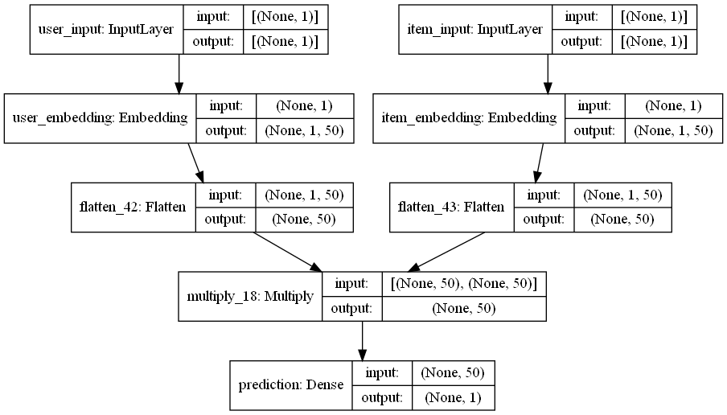

```python
from keras.utils.vis_utils import plot_model
plot_model(model, to_file='model_plot.png', show_shapes=True, show_layer_names=True)
```

```python
model.compile(optimizer=RMSprop(lr=0.001), metrics = ['accuracy', recall],  loss='binary_crossentropy')

# Train Model
early_stop = EarlyStopping(monitor='val_loss', min_delta=0.01, patience=3, verbose=1)
history = model.fit([X[:,0], X[:,1]], X[:,2], batch_size=150000, epochs=20, validation_split = 0.1, verbose=1, callbacks = [early_stop])
score = model.evaluate([testw['userId'].cat.codes.values, testw['movieId'].cat.codes.values], np.ones(testw.shape[0]), verbose=1, batch_size=100000)
print(f'Test Loss: {score[0]}   |   Test Recall: {score[1]}')
```

```
Epoch 00004: early stopping
Test Loss: 0.6886199712753296   |   Test Recall: 1.0
```

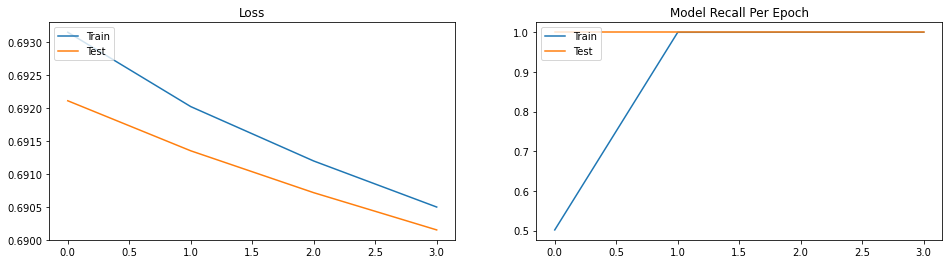

```python
# Plot it
import matplotlib.pyplot as plt
fig, (axis1,axis2) = plt.subplots(1,2, figsize=(16,4))
axis1.plot(history.history['loss'])
axis1.plot(history.history['val_loss'])
axis1.set_title('Loss')
axis1.legend(['Train', 'Test'], loc='upper left')
axis2.plot(history.history['recall'])
axis2.plot(history.history['val_recall'])
axis2.set_title('Model Recall Per Epoch')
axis2.legend(['Train', 'Test'], loc='upper left')
plt.show()
```

```python
# compute MPR
# we implement per chunk to handle memory issues
user_index = testw['userId'].cat.codes.values
item_index = testw['movieId'].cat.codes.values
number_of_chunks = 10
chunks = np.array_split(np.arange(n_users), number_of_chunks)
res = []
prev_max = 0
for i,indexx in enumerate(chunks):
    print(f'Implementing chunk : {i+1}/{number_of_chunks}')
    cross_movieId = np.transpose([np.tile(np.arange(num_of_items), len(indexx)), np.repeat(indexx, len(np.arange(num_of_items)))])
    score = model.predict([cross_movieId[:,1], cross_movieId[:,0]], batch_size=50000, verbose=1).reshape(indexx.shape[0], num_of_items)
    score = (-score).argsort() / score.shape[1]
    sel = (user_index >= indexx.min()) & (user_index <= indexx.max())
    chunk_score = np.asarray(score[user_index[sel] - prev_max, item_index[sel]]).reshape(-1)
    res.append(chunk_score)
    prev_max = indexx.max() + 1
mpr_NCF = np.concatenate(res).sum()/len(testw)
print(f'NCF MPR: {mpr_NCF:.5f}')
rec_NCF = (np.concatenate(res) < 0.5).sum()/len(testw)
print(f'NCF Model Recall rate: {rec_NCF:.5f}')
```

```
Implementing chunk : 1/10
Implementing chunk : 2/10
Implementing chunk : 3/10
Implementing chunk : 4/10
Implementing chunk : 5/10
Implementing chunk : 6/10
Implementing chunk : 7/10
Implementing chunk : 8/10
Implementing chunk : 9/10
Implementing chunk : 10/10
NCF MPR: 0.50154
NCF Model Recall rate: 0.50186
```

```python
#Make movie predictions using the deep learning model
test_pred['score'] = list(np.concatenate(res))
#Select the top 5 movieIds to recommend to a user
testf = test_pred.sort_values(['score'],ascending=False).groupby('userId').head(5)
testf1 = testf.sort_values('userId')
testf1 = testf1[['userId', 'movieId']]
testf1.columns = ['userId', 'Recommended movieId']
testf1.head(10)
```

[output not shown]

#### Non-Negative Matrix Factorization

```python
def nmf_model(data, pred, model):
    # normalize to obtain the % importance to user
    scaled_df = data.multiply(1/data.sum(axis=1)).tocsr()
    W = model.fit_transform(scaled_df)
    H = model.components_

    # implement per chunk to handle memory issues
    user_index = pred['userId'].cat.codes.values
    item_index = pred['movieId'].cat.codes.values
    number_of_chunks = 30
    chunks = np.array_split(np.arange(W.shape[0]), number_of_chunks)
    res = []
    prev_max = 0
    for i,indexx in enumerate(chunks):
        print(f'Implementing chunk : {i+1}/{number_of_chunks}')
        score = (W[indexx].dot(H))
        score = (-score).argsort() / score.shape[1]
        sel = (user_index >= indexx.min()) & (user_index <= indexx.max())
        chunk_score = np.asarray(score[user_index[sel] - prev_max, item_index[sel]]).reshape(-1)
        res.append(chunk_score)
        prev_max = indexx.max() + 1
    return np.concatenate(res)

K = 2

# NMF
#NNDSVD with zeros filled with the average of X (better when sparsity is not desired)
model = NMF(n_components = K, init = 'nndsvd', max_iter = 1000, tol = 0.1, random_state = 1)
Recommendations1 = nmf_model(train_df, testw, model)
mpr_Non_Negative_Matrix_Factorization = Recommendations1.sum()/len(testw)
print(f'NMF MPR: {mpr_Non_Negative_Matrix_Factorization:.5f}')
rec_Non_Negative_Matrix_Factorization = (Recommendations1 < 0.5).sum()/len(testw)
print(f'Model Recall rate: {rec_Non_Negative_Matrix_Factorization:.5f}')
```

[output not shown]

# 10M MovieLens dataset

> Source: https://files.grouplens.org/datasets/movielens/ml-10m.zip

```python
# Reading ratings file
ratings = pd.read_csv('ml-10m/ratings.dat', sep='::',
                      names=['userId', 'movieId', 'rating', 'timestamp']
                      ).sort_values("timestamp")
# Reading movies file
movies = pd.read_csv('ml-10m/movies.dat', sep='::',
                     header=None, names=['movieId', 'title', 'genres'])
```

```python
df_movie = movies
df_ratings = ratings
```

```python
df_movies1 = df_movie.merge(df_ratings)[['genres', 'rating']]
```

#### Examine data sparsity

```python
users = list(np.sort(ratings.userId.unique())) # Get our unique customers
movies = list(ratings.movieId.unique()) # Get our unique products that were purchased
rating = list(ratings.rating) # All of our purchases
rows = ratings.userId.astype('category', users).cat.codes
# pull row indices
cols = ratings.movieId.astype('category', movies).cat.codes
# pull column indices
user_item = sparse.csr_matrix((rating, (rows, cols)), shape=(len(users), len(movies)))
matrix_size = user_item.shape[0]*user_item.shape[1] # Number of possible interactions in the matrix
num_purchases = len(user_item.nonzero()[0]) # Number of items interacted with
sparsity = 100*(1 - (1.0*num_purchases/matrix_size))
print(f'{round(sparsity,4)} % Sparsity')
```

```
98.6597 % Sparsity
```

```python
print(num_purchases, 'interactions')
```

```
10000054 interactions
```

```python
print(len(movies), 'Items')
```

```
10677 Items
```

```python
print(len(users), 'Users')
```

```
69878 Users
```

### Exploratory Data Analysis(EDA)

```python
df_movie.head(5)
```

|  | movieId | title | genres |
| --- | --- | --- | --- |
| 0 | 1 | Toy Story (1995) | Adventure\|Animation\|Children\|Comedy\|Fantasy |
| 1 | 2 | Jumanji (1995) | Adventure\|Children\|Fantasy |
| 2 | 3 | Grumpier Old Men (1995) | Comedy\|Romance |
| 3 | 4 | Waiting to Exhale (1995) | Comedy\|Drama\|Romance |
| 4 | 5 | Father of the Bride Part II (1995) | Comedy |

[figure not shown]

```python
plt.figure(figsize=(20,7))
genrelist = df_movies1['genres'].apply(lambda genrelist_movie : str(genrelist_movie).split("|"))
genres_count = {}

for genrelist_movie in genrelist:
    for genre in genrelist_movie:
        if(genres_count.get(genre,False)):
            genres_count[genre]=genres_count[genre]+1
        else:
            genres_count[genre] = 1

genres_count.pop('(no genres listed)')
genres_count = {k: v for k, v in sorted(genres_count.items(), key=lambda item: item[1], reverse=True)}
plt.bar(genres_count.keys(),genres_count.values(),color='steelblue')
plt.title('Distribution of number of movies by genre')
plt.xlabel('Genre')
plt.ylabel('Number of movies')
plt.grid()
plt.show()
```

```python
df_ratings.head(5)
```

|  | userId | movieId | rating | timestamp |
| --- | --- | --- | --- | --- |
| 5167075 | 36955 | 21 | 3.0 | 789652009 |
| 5167081 | 36955 | 47 | 5.0 | 789652009 |
| 5167124 | 36955 | 1079 | 3.0 | 789652009 |
| 4961485 | 35435 | 45 | 5.0 | 822873600 |
| 4961483 | 35435 | 21 | 5.0 | 822873600 |

### Distribution of users rating

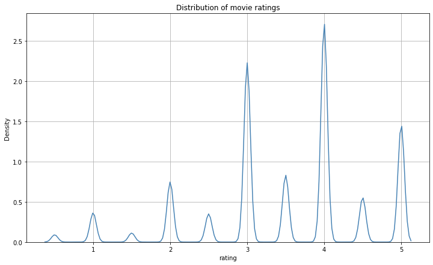

```python
plt.figure(figsize=(12,7))
sns.kdeplot(df_ratings["rating"], color = 'steelblue');
plt.title('Distribution of movie ratings')
plt.grid()
plt.show()
```

```python
print("Shape of the dataframes: \n"+ " Rating DataFrame: "+ str(df_ratings.shape)+"\n Movies DataFrame"+ str(df_movie.shape))
```

```
Shape of the dataframes:
 Rating DataFrame: (10000054, 4)
 Movies DataFrame(10681, 3)
```

```python
combine_movie_ratings = pd.merge(df_movie, df_ratings, on='movieId', how='inner')
```

```python
combine_movie_ratings.head(2)
```

|  | movieId | title | genres | userId | rating | timestamp |
| --- | --- | --- | --- | --- | --- | --- |
| 0 | 1 | Toy Story (1995) | Adventure\|Animation\|Children\|Comedy\|Fantasy | 35139 | 4.0 | 822873600 |
| 1 | 1 | Toy Story (1995) | Adventure\|Animation\|Children\|Comedy\|Fantasy | 36008 | 5.0 | 823185203 |

```python
combine_movie_ratings = combine_movie_ratings.drop('timestamp', axis=1)
```

```python
combine_movie_ratings.shape
```

```
(10000054, 5)
```

Grouping the rating based on user

```python
ratings_grouped_by_users = combine_movie_ratings.groupby('userId').agg([np.size, np.mean])
```

```python
ratings_grouped_by_users.head(2)
```

| userId | movieId size | movieId mean | rating size | rating mean |
| --- | --- | --- | --- | --- |
| 1 | 22 | 411.681818 | 22.0 | 5.0 |
| 2 | 20 | 785.550000 | 20.0 | 3.2 |

```python
ratings_grouped_by_users = ratings_grouped_by_users.drop('movieId', axis = 1)
```

### Top 10 users who have rated most of the movies

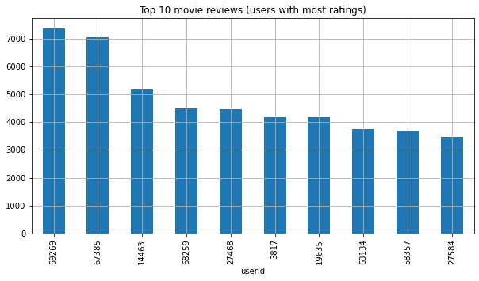

```python
ratings_grouped_by_users['rating']['size'].sort_values(ascending=False).head(10).plot(kind = 'bar', figsize = (10,5))
plt.title('Top 10 movie reviews (users with most ratings)')
plt.grid()
plt.show()
```

```python
ratings_movies = combine_movie_ratings.groupby('movieId').agg([np.mean], np.size)
```

```python
ratings_movies.shape
```

```
(10677, 2)
```

```python
ratings_movies.head(3)
```

| movieId | userId mean | rating mean |
| --- | --- | --- |
| 1 | 35520.163787 | 3.928769 |
| 2 | 35868.424701 | 3.208070 |
| 3 | 35311.554685 | 3.150385 |

```python
ratings_movies = ratings_movies.drop('userId', axis=1)
```

### Movies with high average rating

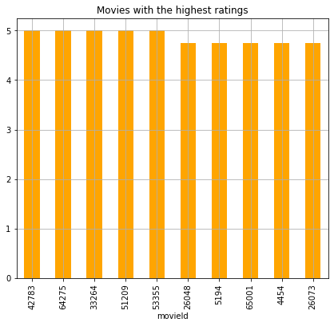

```python
ratings_movies['rating']['mean'].sort_values(ascending=False).head(10).plot(kind='bar',
                                                                                       figsize=(7,6), color = 'orange');
plt.title('Movies with the highest ratings')
plt.grid()
plt.show()
```

### Movies with low average rating

```python
least_rated_movies = ratings_movies['rating']['mean']< 1.5
```

```python
rated_low = ratings_movies[least_rated_movies]
```

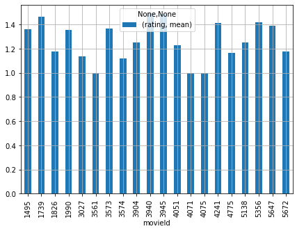

```python
rated_low.head(20).plot(kind='bar', figsize=(8,6));
plt.grid()
```

```python
rated_low.head(10)
```

| movieId | rating mean |
| --- | --- |
| 1495 | 1.360227 |
| 1739 | 1.464286 |
| 1826 | 1.175214 |
| 1990 | 1.356436 |
| 3027 | 1.138889 |
| 3561 | 1.000000 |
| 3573 | 1.367647 |
| 3574 | 1.120253 |
| 3904 | 1.250000 |
| 3940 | 1.491667 |

```python
#Merge
df_movies = df_movie.merge(df_ratings)

groupby = ['genres']
nonnormal = ['movieId']

df_movies = df_movies[df_movies['genres'].isin(list(genres_count.keys())[0:5])]
```

```python
TestTable = TableOne(df_movies,columns = ['genres', 'rating'],
                   groupby=groupby, pval=True)
```

```python
TestTable
```

|  |  | Grouped by genres Missing | Grouped by genres Overall | Grouped by genres Action | Grouped by genres Adventure | Grouped by genres Comedy | Grouped by genres Drama | Grouped by genres Thriller | Grouped by genres P-Value |
| --- | --- | --- | --- | --- | --- | --- | --- | --- | --- |
| n |  |  | 1728711 | 27208 | 2549 | 778596 | 815084 | 105274 |  |
| rating, n (%) | 0.5 | 0 | 16147 (0.9) | 428 (1.6) | 53 (2.1) | 11301 (1.5) | 3895 (0.5) | 470 (0.4) | <0.001 |
|  | 1.0 |  | 76002 (4.4) | 2666 (9.8) | 245 (9.6) | 50350 (6.5) | 19796 (2.4) | 2945 (2.8) |  |
|  | 1.5 |  | 19674 (1.1) | 614 (2.3) | 62 (2.4) | 13280 (1.7) | 4938 (0.6) | 780 (0.7) |  |
|  | 2.0 |  | 145057 (8.4) | 3750 (13.8) | 365 (14.3) | 86532 (11.1) | 46460 (5.7) | 7950 (7.6) |  |
|  | 2.5 |  | 61721 (3.6) | 1400 (5.1) | 137 (5.4) | 35875 (4.6) | 20886 (2.6) | 3423 (3.3) |  |
|  | 3.0 |  | 422363 (24.4) | 9217 (33.9) | 698 (27.4) | 209441 (26.9) | 175215 (21.5) | 27792 (26.4) |  |
|  | 3.5 |  | 142369 (8.2) | 1763 (6.5) | 243 (9.5) | 65123 (8.4) | 66364 (8.1) | 8876 (8.4) |  |
|  | 4.0 |  | 500639 (29.0) | 5344 (19.6) | 524 (20.6) | 192115 (24.7) | 267806 (32.9) | 34850 (33.1) |  |
|  | 4.5 |  | 88418 (5.1) | 434 (1.6) | 69 (2.7) | 31050 (4.0) | 52679 (6.5) | 4186 (4.0) |  |
|  | 5.0 |  | 256321 (14.8) | 1592 (5.9) | 153 (6.0) | 83529 (10.7) | 157045 (19.3) | 14002 (13.3) |  |

```python
TestTable.to_excel('summary_10M.xlsx')
```

```python
TestTable = TableOne(df_movies,columns = ['genres', 'rating'],
                   groupby=groupby, categorical=['genres'], nonnormal=nonnormal, pval=True, tukey_test=True)

display(TestTable)

TestTable.to_excel('summary_10M_test.xlsx')
```

|  |  | Grouped by genres Missing | Grouped by genres Overall | Grouped by genres Action | Grouped by genres Adventure | Grouped by genres Comedy | Grouped by genres Drama | Grouped by genres Thriller | Grouped by genres P-Value |
| --- | --- | --- | --- | --- | --- | --- | --- | --- | --- |
| n |  |  | 1728711 | 27208 | 2549 | 778596 | 815084 | 105274 |  |
| genres, n (%) | Action | 0 | 27208 (1.6) | 27208 (100.0) |  |  |  |  | <0.001 |
|  | Adventure |  | 2549 (0.1) |  | 2549 (100.0) |  |  |  |  |
|  | Comedy |  | 778596 (45.0) |  |  | 778596 (100.0) |  |  |  |
|  | Drama |  | 815084 (47.1) |  |  |  | 815084 (100.0) |  |  |
|  | Thriller |  | 105274 (6.1) |  |  |  |  | 105274 (100.0) |  |
| rating, mean (SD) |  | 0 | 3.5 (1.1) | 2.9 (1.1) | 3.0 (1.1) | 3.2 (1.1) | 3.7 (1.0) | 3.5 (1.0) | <0.001 |

[1] Chi-squared tests for the following variables may be invalid due to the low number of observations: genres.

#### Data Preparation

> (1)- Merge the dataframes to obtain complete information regarding a user, a movie and the corresponding interaction.

> (2)- Split the data into test and train.

##### Merge the dataframes

```python
df_ratings.columns
```

```
Index(['userId', 'movieId', 'rating', 'timestamp'], dtype='object')
```

```python
df_movies.columns
```

```
Index(['movieId', 'title', 'genres', 'userId', 'rating', 'timestamp'], dtype='object')
```

```python
#Merge the dataframes
movie_ratings = df_movies.merge(df_ratings)
movie_ratings = movie_ratings
movie_ratings.head()
```

|  | movieId | title | genres | userId | rating | timestamp |
| --- | --- | --- | --- | --- | --- | --- |
| 0 | 5 | Father of the Bride Part II (1995) | Comedy | 36008 | 2.0 | 823185224 |
| 1 | 5 | Father of the Bride Part II (1995) | Comedy | 36304 | 4.0 | 823264601 |
| 2 | 5 | Father of the Bride Part II (1995) | Comedy | 38104 | 4.0 | 825006881 |
| 3 | 5 | Father of the Bride Part II (1995) | Comedy | 38206 | 2.0 | 825009968 |
| 4 | 5 | Father of the Bride Part II (1995) | Comedy | 38326 | 4.0 | 825080156 |

##### Split the dataframes to test and train sets

```python
X = movie_ratings[['userId', 'movieId']].values
y = movie_ratings['rating'].values
X_train, X_test, y_train, y_test = train_test_split(X, y, test_size=0.3, random_state=42)
X_train.shape, X_test.shape, y_train.shape, y_test.shape
```

```
((1210097, 2), (518614, 2), (1210097,), (518614,))
```

#### Modeling

```python
X = movie_ratings[['userId', 'movieId']]
y = movie_ratings['rating']
X_train, X_test, y_train, y_test = train_test_split(X, y, test_size=0.3, random_state=42)
```

### Step 1. Define an index vector of all unique users and movies

```python
#Order the items and users
c_movie = CategoricalDtype(sorted(movie_ratings['movieId'].unique()), ordered=True)
c_user = CategoricalDtype(sorted(movie_ratings['userId'].unique()), ordered=True)
```

```python
print(len(c_movie.categories))
print(len(c_user.categories))
```

```
3103
69076
```

```python
train, test = train_test_split(X, test_size=0.30, random_state=420)
print(train.shape)
print(test.shape)
```

```
(1210097, 2)
(518614, 2)
```

```python
test = X_test.copy()
train = X_train.copy()

testw = test.copy()

testw['userId'] = test['userId'].astype(c_user)

testw['movieId'] = test['movieId'].astype(c_movie)

test_pred = testw.copy()
```

```python
testw.info()
```

```
<class 'pandas.core.frame.DataFrame'>
Int64Index: 518614 entries, 1713321 to 710290
Data columns (total 2 columns):
 #   Column   Non-Null Count   Dtype
---  ------   --------------   -----
 0   userId   518614 non-null  category
 1   movieId  518614 non-null  category
dtypes: category(2)
memory usage: 9.6 MB
```

### Step 2: Define a 1/0 binary sparse matrix of User-items for training set

```python
from scipy.sparse import  csr_matrix
train_df = csr_matrix((np.ones(len(train)), (train['userId'].astype('category').cat.codes,
                                               train['movieId'].astype('category').cat.codes)),
                  shape=( len(c_user.categories), len(c_movie.categories)))
print(f'{100*train_df.sum()/(train_df.shape[0]*train_df.shape[1])}% Sparsity')
```

[output not shown]

### Step 3. Run the model on the training set

Models were testing:

1. Simple Cosine Similarity on items
2. Non-negative matrix factorization
3. Simple Neural Collaborative Filtering

Evaluation:

- Recall: % of 1s in the Test set
- MPR: Mean Percentile Rank

#### Simple Cosine Similarity

Doing this in chunks for the test set so that we don't run into memory issues. For the recall measure, if the track's relative percentile is < 0.5 then its a 1

```python
# Simple Cosine Similarity
from scipy.stats import percentileofscore
def simple_cosine(data, pred):
    from sklearn.metrics.pairwise import cosine_similarity
    #Cosine similarity model to generate a matrix and determine the closest recommendation depending on the similarity matrix

    # normalize to obtain the % importance to user
    scaled_df = data.multiply(1/data.sum(axis=1)).tocsr()
    # implement cosine similarity
    sim = cosine_similarity(scaled_df.transpose(), dense_output=False)
    sim[np.diag_indices(sim.shape[0])] = 0
    denom = np.asarray(sim.sum(axis=1)).reshape(-1)

    # implement per chunk to handle memory issues
    user_index = pred['userId'].cat.codes.values
    item_index = pred['movieId'].cat.codes.values

    number_of_chunks = 30
    chunks = np.array_split(np.arange(scaled_df.shape[0]), number_of_chunks)
    res = []
    prev_max = 0
    for i,indexx in enumerate(chunks):
        print(f'Implementing chunk : {i+1}/{number_of_chunks}')
        score = (scaled_df[indexx].dot(sim)) / denom
        score = (-score).argsort() / denom.shape[0]
        sel = (user_index >= indexx.min()) & (user_index <= indexx.max())
        chunk_score = np.asarray(score[user_index[sel] - prev_max, item_index[sel]]).reshape(-1)
        res.append(chunk_score)
        prev_max = indexx.max() + 1
    return np.concatenate(res)


# Evaluate performance of the model
Recommendations = simple_cosine(train_df, testw)
mpr_cosine_sim = Recommendations.sum()/len(testw)
print(f'MPR: {mpr_cosine_sim:.5f}')
rec_cosine_sim = (Recommendations < 0.5).sum()/len(testw)
print(f'Model Recall rate: {rec_cosine_sim:.5f}')
```

```
Implementing chunk : 1/30
Implementing chunk : 2/30
Implementing chunk : 3/30
Implementing chunk : 4/30
Implementing chunk : 5/30
Implementing chunk : 6/30
Implementing chunk : 7/30
Implementing chunk : 8/30
Implementing chunk : 9/30
Implementing chunk : 10/30
Implementing chunk : 11/30
Implementing chunk : 12/30
Implementing chunk : 13/30
Implementing chunk : 14/30
Implementing chunk : 15/30
Implementing chunk : 16/30
Implementing chunk : 17/30
Implementing chunk : 18/30
Implementing chunk : 19/30
Implementing chunk : 20/30
Implementing chunk : 21/30
Implementing chunk : 22/30
Implementing chunk : 23/30
Implementing chunk : 24/30
Implementing chunk : 25/30
Implementing chunk : 26/30
Implementing chunk : 27/30
Implementing chunk : 28/30
Implementing chunk : 29/30
Implementing chunk : 30/30
MPR: 0.40586
Model Recall rate: 0.64690
```

#### Neural Collaborative Filtering

```python
# Create the Training Set
sample_size_with_no_interactions = int(len(train)*0.2)
n_users = c_user.categories.shape[0]
num_of_items = c_movie.categories.shape[0]
# Create Training Set
trnx_users = train['userId'].astype('category').cat.codes.values
trnx_items = train['movieId'].astype('category').cat.codes.values
train_labels = np.ones(len(trnx_users))
# insert negative samples
u = np.random.randint(n_users, size=sample_size_with_no_interactions)
i = np.random.randint(num_of_items, size=sample_size_with_no_interactions)
non_neg_indexx = np.where(train_df[u,i] == 0)
trnx_users = np.concatenate([trnx_users, u[non_neg_indexx[1]]])
trnx_items = np.concatenate([trnx_items, i[non_neg_indexx[1]]])
train_labels = np.concatenate([train_labels, np.zeros(u[non_neg_indexx[1]].shape[0])])
print((trnx_users.shape, trnx_items.shape, train_labels.shape))

# shuffle the data
X = np.stack([trnx_users, trnx_items, train_labels], axis=1)
np.random.shuffle(X)
```

```
((1450726,), (1450726,), (1450726,))
```

```python
def neural_network_model(number_of_users, num_items, latent_dim, regs=[0,0]):
    # model vars
    user_input = Input(shape=(1,), dtype='int32', name = 'user_input')
    item_input = Input(shape=(1,), dtype='int32', name = 'item_input')

    MF_Embedding_User = Embedding(input_dim = number_of_users, output_dim = latent_dim, name = 'user_embedding',
                                  embeddings_regularizer = l2(regs[0]), input_length=1)
    MF_Embedding_Item = Embedding(input_dim = num_items, output_dim = latent_dim, name = 'item_embedding',
                                  embeddings_regularizer = l2(regs[1]), input_length=1)

    # essential to define an embedding vector!
    user_latent = Flatten()(MF_Embedding_User(user_input))
    item_latent = Flatten()(MF_Embedding_Item(item_input))

    # user-item embedding productper element
    predict_vector = merge.Multiply()([user_latent, item_latent])

    # Final prediction layer
    prediction = Dense(1, activation='sigmoid', kernel_initializer='lecun_uniform', name = 'prediction')(predict_vector)

    model = Model(inputs=[user_input, item_input], outputs=prediction)

    return model

# create the model
def recall(y_true, y_pred):
    tp = K.sum(K.round(K.clip(y_true * y_pred, 0, 1)))
    pos_pt = K.sum(K.round(K.clip(y_true, 0, 1)))
    recall = tp / (pos_pt + K.epsilon())
    return recall

model = neural_network_model(n_users, num_of_items, 50, regs = [0,0])
```

```python
model.summary()
```

```
Model: "model_2"
__________________________________________________________________________________________________
Layer (type)                    Output Shape         Param #     Connected to
==================================================================================================
user_input (InputLayer)         [(None, 1)]          0
__________________________________________________________________________________________________
item_input (InputLayer)         [(None, 1)]          0
__________________________________________________________________________________________________
user_embedding (Embedding)      (None, 1, 50)        3453800     user_input[0][0]
__________________________________________________________________________________________________
item_embedding (Embedding)      (None, 1, 50)        155150      item_input[0][0]
__________________________________________________________________________________________________
flatten_8 (Flatten)             (None, 50)           0           user_embedding[0][0]
__________________________________________________________________________________________________
flatten_9 (Flatten)             (None, 50)           0           item_embedding[0][0]
__________________________________________________________________________________________________
multiply_2 (Multiply)           (None, 50)           0           flatten_8[0][0]
                                                                 flatten_9[0][0]
__________________________________________________________________________________________________
prediction (Dense)              (None, 1)            51          multiply_2[0][0]
==================================================================================================
Total params: 3,609,001
Trainable params: 3,609,001
Non-trainable params: 0
__________________________________________________________________________________________________
```

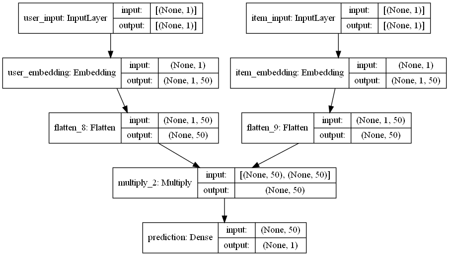

```python
from keras.utils.vis_utils import plot_model
plot_model(model, to_file='model_plot.png', show_shapes=True, show_layer_names=True)
```

```python
model.compile(optimizer=RMSprop(lr=0.001), metrics = ['accuracy', recall],  loss='binary_crossentropy')

# Train Model
early_stop = EarlyStopping(monitor='val_loss', min_delta=0.01, patience=3, verbose=1)
history = model.fit([X[:,0], X[:,1]], X[:,2], batch_size=150000, epochs=20, validation_split = 0.1, verbose=1, callbacks = [early_stop])
score = model.evaluate([testw['userId'].cat.codes.values, testw['movieId'].cat.codes.values], np.ones(testw.shape[0]), verbose=1, batch_size=100000)
print(f'Test Loss: {score[0]}   |   Test Recall: {score[1]}')
```

```
Epoch 00004: early stopping
Test Loss: 0.6709330677986145   |   Test Recall: 1.0
```

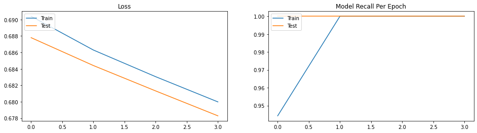

```python
# Plot it
import matplotlib.pyplot as plt
fig, (axis1,axis2) = plt.subplots(1,2, figsize=(16,4))
axis1.plot(history.history['loss'])
axis1.plot(history.history['val_loss'])
axis1.set_title('Loss')
axis1.legend(['Train', 'Test'], loc='upper left')
axis2.plot(history.history['recall'])
axis2.plot(history.history['val_recall'])
axis2.set_title('Model Recall Per Epoch')
axis2.legend(['Train', 'Test'], loc='upper left')
plt.show()
```

```python
# compute MPR
# we implement per chunk to handle memory issues
user_index = testw['userId'].cat.codes.values
item_index = testw['movieId'].cat.codes.values
number_of_chunks = 10
chunks = np.array_split(np.arange(n_users), number_of_chunks)
res = []
prev_max = 0
for i,indexx in enumerate(chunks):
    print(f'Implementing chunk : {i+1}/{number_of_chunks}')
    cross_movieId = np.transpose([np.tile(np.arange(num_of_items), len(indexx)), np.repeat(indexx, len(np.arange(num_of_items)))])
    score = model.predict([cross_movieId[:,1], cross_movieId[:,0]], batch_size=50000, verbose=1).reshape(indexx.shape[0], num_of_items)
    score = (-score).argsort() / score.shape[1]
    sel = (user_index >= indexx.min()) & (user_index <= indexx.max())
    chunk_score = np.asarray(score[user_index[sel] - prev_max, item_index[sel]]).reshape(-1)
    res.append(chunk_score)
    prev_max = indexx.max() + 1
mpr_NCF = np.concatenate(res).sum()/len(testw)
print(f'NCF MPR: {mpr_NCF:.5f}')
rec_NCF = (np.concatenate(res) < 0.5).sum()/len(testw)
print(f'NCF Model Recall rate: {rec_NCF:.5f}')
```

```
Implementing chunk : 1/10
Implementing chunk : 2/10
Implementing chunk : 3/10
Implementing chunk : 4/10
Implementing chunk : 5/10
Implementing chunk : 6/10
Implementing chunk : 7/10
Implementing chunk : 8/10
Implementing chunk : 9/10
Implementing chunk : 10/10
NCF MPR: 0.49349
NCF Model Recall rate: 0.51037
```

```python
#Make movie predictions using the deep learning model
test_pred['score'] = list(np.concatenate(res))
#Select the top 5 movieIds to recommend to a user
testf = test_pred.sort_values(['score'],ascending=False).groupby('userId').head(5)
testf1 = testf.sort_values('userId')
testf1 = testf1[['userId', 'movieId']]
testf1.columns = ['userId', 'Recommended movieId']
testf1.head(10)
```

|  | userId | Recommended movieId |
| --- | --- | --- |
| 676471 | 3 | 1276 |
| 330433 | 4 | 410 |
| 158401 | 4 | 231 |
| 625960 | 5 | 1207 |
| 633980 | 5 | 1225 |
| 677414 | 5 | 1280 |
| 525124 | 5 | 926 |
| 268965 | 5 | 334 |
| 630097 | 7 | 1207 |
| 918395 | 7 | 2335 |

#### Non-Negative Matrix Factorization

```python
def nmf_model(data, pred, model):
    # normalize to obtain the % importance to user
    scaled_df = data.multiply(1/data.sum(axis=1)).tocsr()
    W = model.fit_transform(scaled_df)
    H = model.components_

    # implement per chunk to handle memory issues
    user_index = pred['userId'].cat.codes.values
    item_index = pred['movieId'].cat.codes.values
    number_of_chunks = 30
    chunks = np.array_split(np.arange(W.shape[0]), number_of_chunks)
    res = []
    prev_max = 0
    for i,indexx in enumerate(chunks):
        print(f'Implementing chunk : {i+1}/{number_of_chunks}')
        score = (W[indexx].dot(H))
        score = (-score).argsort() / score.shape[1]
        sel = (user_index >= indexx.min()) & (user_index <= indexx.max())
        chunk_score = np.asarray(score[user_index[sel] - prev_max, item_index[sel]]).reshape(-1)
        res.append(chunk_score)
        prev_max = indexx.max() + 1
    return np.concatenate(res)

K = 2

# NMF
#NNDSVD with zeros filled with the average of X (better when sparsity is not desired)
model = NMF(n_components = K, init = 'nndsvd', max_iter = 1000, tol = 0.1, random_state = 1)
Recommendations1 = nmf_model(train_df, testw, model)
mpr_Non_Negative_Matrix_Factorization = Recommendations1.sum()/len(testw)
print(f'NMF MPR: {mpr_Non_Negative_Matrix_Factorization:.5f}')
rec_Non_Negative_Matrix_Factorization = (Recommendations1 < 0.5).sum()/len(testw)
print(f'Model Recall rate: {rec_Non_Negative_Matrix_Factorization:.5f}')
```

[output not shown]

# "Learning from sets data 2019" DATA:

> Source: https://grouplens.org/datasets/learning-from-sets-of-items-2019/

```python
# Reading ratings file
movie_ratings = pd.read_csv('learning-from-sets-2019/item_ratings.csv',
                      names=['userId', 'movieId', 'rating', 'timestamp']
                      ).sort_values("timestamp")
#Drop rows that have nonnumeric movie ID
movie_ratings = movie_ratings[movie_ratings.movieId.str.isnumeric().isnull()]
#Convert data types for movieId and rating
movie_ratings['movieId'] = pd.to_numeric(movie_ratings.movieId)
movie_ratings['rating'] = pd.to_numeric(movie_ratings.rating)

# Reading movies file
movie_1 = pd.read_csv('learning-from-sets-2019/set_ratings.csv')
```

```python
movies_1 = movie_ratings.copy()
users = list(np.sort(movie_ratings.userId.unique())) # Get our unique customers
movies_1 = list(movie_ratings.movieId.unique()) # Get our unique products that were purchased
rating = list(movie_ratings.rating) # All of our purchases
rows = movie_ratings.userId.astype('category', users).cat.codes
# pull row indices
cols = movie_ratings.movieId.astype('category', movies_1).cat.codes
# pull column indices
user_item = sparse.csr_matrix((rating, (rows, cols)), shape=(len(users), len(movies_1)))
matrix_size = user_item.shape[0]*user_item.shape[1] # Number of possible interactions in the matrix
num_purchases = len(user_item.nonzero()[0]) # Number of items interacted with
sparsity = 100*(1 - (1.0*num_purchases/matrix_size))
print(f'{round(sparsity,4)} % Sparsity')
```

```
96.4581 % Sparsity
```

```python
movie_ratings.head()
```

|  | userId | movieId | rating | timestamp |
| --- | --- | --- | --- | --- |
| 131258 | 1861f05e46 | 2001 | 3.5 | 2005-03-29 16:19:32 |
| 131132 | 1861f05e46 | 1250 | 3.5 | 2005-03-29 16:20:20 |
| 131105 | 1861f05e46 | 1204 | 3.5 | 2005-03-29 16:20:33 |
| 131235 | 1861f05e46 | 1876 | 3.0 | 2005-03-29 16:21:37 |
| 131600 | 1861f05e46 | 4886 | 5.0 | 2005-03-29 16:21:41 |

```python
print(num_purchases, 'interactions')

print(len(movies_1), 'Items')

print(len(users), 'Users')
```

```
327899 interactions
12443 Items
744 Users
```

```python
movie_ratings.head()
```

|  | userId | movieId | rating | timestamp |
| --- | --- | --- | --- | --- |
| 131258 | 1861f05e46 | 2001 | 3.5 | 2005-03-29 16:19:32 |
| 131132 | 1861f05e46 | 1250 | 3.5 | 2005-03-29 16:20:20 |
| 131105 | 1861f05e46 | 1204 | 3.5 | 2005-03-29 16:20:33 |
| 131235 | 1861f05e46 | 1876 | 3.0 | 2005-03-29 16:21:37 |
| 131600 | 1861f05e46 | 4886 | 5.0 | 2005-03-29 16:21:41 |

## Exploratory Data Analysis(EDA)

```python
X = movie_ratings[['userId', 'movieId',]]
y = movie_ratings['rating']
X_train, X_test, y_train, y_test = train_test_split(X, y, test_size=0.3, random_state=42)
```

```python
df_movies.head(5)
```

[output not shown]

### Distribution of users rating

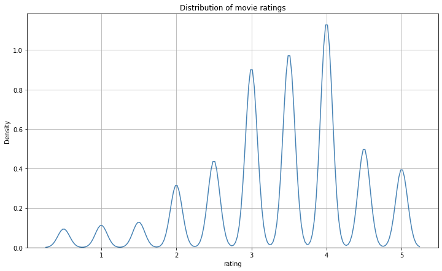

```python
plt.figure(figsize=(12,7))
sns.kdeplot(movie_ratings["rating"], color = 'steelblue');
plt.title('Distribution of movie ratings')
plt.grid()
plt.show()
```

```python
df_ratings = df_movies = movie_ratings
df_ratings.head(5)
```

|  | userId | movieId | rating | timestamp |
| --- | --- | --- | --- | --- |
| 131258 | 1861f05e46 | 2001 | 3.5 | 2005-03-29 16:19:32 |
| 131132 | 1861f05e46 | 1250 | 3.5 | 2005-03-29 16:20:20 |
| 131105 | 1861f05e46 | 1204 | 3.5 | 2005-03-29 16:20:33 |
| 131235 | 1861f05e46 | 1876 | 3.0 | 2005-03-29 16:21:37 |
| 131600 | 1861f05e46 | 4886 | 5.0 | 2005-03-29 16:21:41 |

```python
print("Shape of the dataframes: \n"+ " Rating DataFrame: "+ str(df_ratings.shape)+"\n Movies DataFrame"+ str(df_movies.shape))
```

```
Shape of the dataframes:
 Rating DataFrame: (327899, 4)
 Movies DataFrame(327899, 4)
```

```python
ratings_grouped_by_users = movie_ratings.groupby('userId').agg([np.size, np.mean])
```

```python
ratings_grouped_by_users.head(2)
```

| userId | movieId size | movieId mean | rating size | rating mean |
| --- | --- | --- | --- | --- |
| 0011a9baea | 172 | 53528.569767 | 172.0 | 4.151163 |
| 00be0326d6 | 277 | 34154.996390 | 277.0 | 2.444043 |

```python
ratings_grouped_by_users = ratings_grouped_by_users.drop('movieId', axis = 1)
```

### Top 10 users who have rated most of the movies

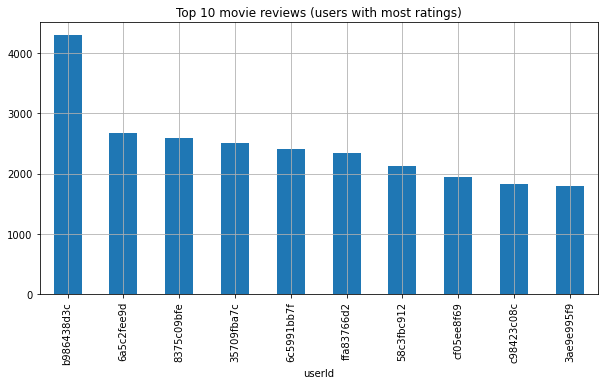

```python
ratings_grouped_by_users['rating']['size'].sort_values(ascending=False).head(10).plot(kind = 'bar', figsize = (10,5))
plt.title('Top 10 movie reviews (users with most ratings)')
plt.grid()
plt.show()
```

```python
ratings_movies = movie_ratings.groupby('movieId').agg([np.mean], np.size)
```

```python
ratings_movies.shape
```

```
(12443, 1)
```

```python
ratings_movies.head(3)
```

| movieId | rating mean |
| --- | --- |
| 1 | 3.727064 |
| 2 | 3.172340 |
| 3 | 3.068966 |

### Movies with high average rating

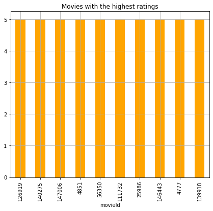

```python
ratings_movies['rating']['mean'].sort_values(ascending=False).head(10).plot(kind='bar', figsize=(7,6), color = 'orange');
plt.title('Movies with the highest ratings')
plt.grid()
plt.show()
```

### Movies with low average rating

```python
least_rated_movies = ratings_movies['rating']['mean']< 1.5
```

```python
rated_low = ratings_movies[least_rated_movies]
```

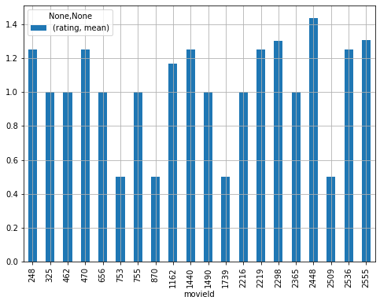

```python
rated_low.head(20).plot(kind='bar', figsize=(8,6));
plt.grid()
```

```python
rated_low.head(10)
```

| movieId | rating mean |
| --- | --- |
| 248 | 1.250000 |
| 325 | 1.000000 |
| 462 | 1.000000 |
| 470 | 1.250000 |
| 656 | 1.000000 |
| 753 | 0.500000 |
| 755 | 1.000000 |
| 870 | 0.500000 |
| 1162 | 1.166667 |
| 1440 | 1.250000 |

##### Merge the dataframes

```python
df_ratings.columns
```

```
Index(['userId', 'movieId', 'rating', 'timestamp'], dtype='object')
```

```python
df_movies.columns
```

```
Index(['userId', 'movieId', 'rating', 'timestamp'], dtype='object')
```

```python
#Merge the dataframes
movie_ratings = df_movies
movie_ratings.head()
```

|  | userId | movieId | rating | timestamp |
| --- | --- | --- | --- | --- |
| 131258 | 1861f05e46 | 2001 | 3.5 | 2005-03-29 16:19:32 |
| 131132 | 1861f05e46 | 1250 | 3.5 | 2005-03-29 16:20:20 |
| 131105 | 1861f05e46 | 1204 | 3.5 | 2005-03-29 16:20:33 |
| 131235 | 1861f05e46 | 1876 | 3.0 | 2005-03-29 16:21:37 |
| 131600 | 1861f05e46 | 4886 | 5.0 | 2005-03-29 16:21:41 |

##### Split the dataframes to test and train sets

```python
X = movie_ratings[['userId', 'movieId']].values
y = movie_ratings['rating'].values
X_train, X_test, y_train, y_test = train_test_split(X, y, test_size=0.3, random_state=42)
X_train.shape, X_test.shape, y_train.shape, y_test.shape
```

```
((229529, 2), (98370, 2), (229529,), (98370,))
```

```python
X = movie_ratings[['userId', 'movieId']]
y = movie_ratings['rating']
X_train, X_test, y_train, y_test = train_test_split(X, y, test_size=0.3, random_state=42)
```

### 1: Define an index vector of all unique users and movies

```python
#Order the items and users
c_movie = CategoricalDtype(sorted(movie_ratings['movieId'].unique()), ordered=True)
c_user = CategoricalDtype(sorted(movie_ratings['userId'].unique()), ordered=True)
```

```python
print(len(c_movie.categories))
print(len(c_user.categories))
```

```
12443
744
```

```python
train, test = train_test_split(X, test_size=0.30, random_state=420)
print(train.shape)
print(test.shape)
```

```
(229529, 2)
(98370, 2)
```

```python
test = X_test.copy()
train = X_train.copy()

testw = test.copy()

testw['userId'] = test['userId'].astype(c_user)

testw['movieId'] = test['movieId'].astype(c_movie)

test_pred = testw.copy()
```

```python
testw.info()
```

```
<class 'pandas.core.frame.DataFrame'>
Int64Index: 98370 entries, 447372 to 304033
Data columns (total 2 columns):
 #   Column   Non-Null Count  Dtype
---  ------   --------------  -----
 0   userId   98370 non-null  category
 1   movieId  98370 non-null  category
dtypes: category(2)
memory usage: 1.5 MB
```

### 2: Create a big 1/0 binary sparse matrix for User-Item in the training set

```python
train_df = csr_matrix((np.ones(len(train)), (train['userId'].astype('category').cat.codes, train['movieId'].astype('category').cat.codes)),
                  shape=( len(c_user.categories), len(c_movie.categories)))
print(f'{100*train_df.sum()/(train_df.shape[0]*train_df.shape[1])}% Sparsity')
```

[output not shown]

```python
# Simple Cosine Similarity

def simple_cosine(data, pred):
    from sklearn.metrics.pairwise import cosine_similarity
    #Cosine similarity model to generate a matrix and determine the closest recommendation depending on the similarity matrix

    # normalize to obtain the % importance to user
    scaled_df = data.multiply(1/data.sum(axis=1)).tocsr()
    # implement cosine similarity
    sim = cosine_similarity(scaled_df.transpose(), dense_output=False)
    sim[np.diag_indices(sim.shape[0])] = 0
    denom = np.asarray(sim.sum(axis=1)).reshape(-1)

    # implement per chunk to handle memory issues
    user_index = pred['userId'].cat.codes.values
    item_index = pred['movieId'].cat.codes.values

    number_of_chunks = 30
    chunks = np.array_split(np.arange(scaled_df.shape[0]), number_of_chunks)
    res = []
    prev_max = 0
    for i,indexx in enumerate(chunks):
        print(f'Implementing chunk : {i+1}/{number_of_chunks}')
        score = (scaled_df[indexx].dot(sim)) / denom
        score = (-score).argsort() / denom.shape[0]
        sel = (user_index >= indexx.min()) & (user_index <= indexx.max())
        chunk_score = np.asarray(score[user_index[sel] - prev_max, item_index[sel]]).reshape(-1)
        res.append(chunk_score)
        prev_max = indexx.max() + 1
    return np.concatenate(res)


# Evaluate performance of the model
Recommendations = simple_cosine(train_df, testw)
mpr_cosine_sim = Recommendations.sum()/len(testw)
print(f'MPR: {mpr_cosine_sim:.5f}')
rec_cosine_sim = (Recommendations < 0.5).sum()/len(testw)
print(f'Model Recall rate: {rec_cosine_sim:.5f}')
```

```
Implementing chunk : 1/30
Implementing chunk : 2/30
Implementing chunk : 3/30
Implementing chunk : 4/30
Implementing chunk : 5/30
Implementing chunk : 6/30
Implementing chunk : 7/30
Implementing chunk : 8/30
Implementing chunk : 9/30
Implementing chunk : 10/30
Implementing chunk : 11/30
Implementing chunk : 12/30
Implementing chunk : 13/30
Implementing chunk : 14/30
Implementing chunk : 15/30
Implementing chunk : 16/30
Implementing chunk : 17/30
Implementing chunk : 18/30
Implementing chunk : 19/30
Implementing chunk : 20/30
Implementing chunk : 21/30
Implementing chunk : 22/30
Implementing chunk : 23/30
Implementing chunk : 24/30
Implementing chunk : 25/30
Implementing chunk : 26/30
Implementing chunk : 27/30
Implementing chunk : 28/30
Implementing chunk : 29/30
Implementing chunk : 30/30
MPR: 0.47469
Model Recall rate: 0.52412
```

#### Neural Collaborative Filtering

```python
# Create the Training Set
sample_size_with_no_interactions = int(len(train)*0.2)
n_users = c_user.categories.shape[0]
num_of_items = c_movie.categories.shape[0]
# Create Training Set
trnx_users = train['userId'].astype('category').cat.codes.values
trnx_items = train['movieId'].astype('category').cat.codes.values
train_labels = np.ones(len(trnx_users))
# insert negative samples
u = np.random.randint(n_users, size=sample_size_with_no_interactions)
i = np.random.randint(num_of_items, size=sample_size_with_no_interactions)
non_neg_indexx = np.where(train_df[u,i] == 0)
trnx_users = np.concatenate([trnx_users, u[non_neg_indexx[1]]])
trnx_items = np.concatenate([trnx_items, i[non_neg_indexx[1]]])
train_labels = np.concatenate([train_labels, np.zeros(u[non_neg_indexx[1]].shape[0])])
print((trnx_users.shape, trnx_items.shape, train_labels.shape))

# shuffle the data
X = np.stack([trnx_users, trnx_items, train_labels], axis=1)
np.random.shuffle(X)
```

```
((274256,), (274256,), (274256,))
```

```python
def neural_network_model(number_of_users, num_items, latent_dim, regs=[0,0]):
    # model vars
    user_input = Input(shape=(1,), dtype='int32', name = 'user_input')
    item_input = Input(shape=(1,), dtype='int32', name = 'item_input')

    MF_Embedding_User = Embedding(input_dim = number_of_users, output_dim = latent_dim, name = 'user_embedding', embeddings_regularizer = l2(regs[0]), input_length=1)
    MF_Embedding_Item = Embedding(input_dim = num_items, output_dim = latent_dim, name = 'item_embedding', embeddings_regularizer = l2(regs[1]), input_length=1)

    # essential to define an embedding vector!
    user_latent = Flatten()(MF_Embedding_User(user_input))
    item_latent = Flatten()(MF_Embedding_Item(item_input))

    # user-item embedding productper element
    predict_vector = merge.Multiply()([user_latent, item_latent])

    # Final prediction layer
    prediction = Dense(1, activation='sigmoid', kernel_initializer='lecun_uniform', name = 'prediction')(predict_vector)

    model = Model(inputs=[user_input, item_input], outputs=prediction)

    return model

# create the model
def recall(y_true, y_pred):
    tp = K.sum(K.round(K.clip(y_true * y_pred, 0, 1)))
    pos_pt = K.sum(K.round(K.clip(y_true, 0, 1)))
    recall = tp / (pos_pt + K.epsilon())
    return recall

model = neural_network_model(n_users, num_of_items, 50, regs = [0,0])
```

```python
model.summary()
```

```
Model: "model_19"
__________________________________________________________________________________________________
Layer (type)                    Output Shape         Param #     Connected to
==================================================================================================
user_input (InputLayer)         [(None, 1)]          0
__________________________________________________________________________________________________
item_input (InputLayer)         [(None, 1)]          0
__________________________________________________________________________________________________
user_embedding (Embedding)      (None, 1, 50)        37200       user_input[0][0]
__________________________________________________________________________________________________
item_embedding (Embedding)      (None, 1, 50)        622150      item_input[0][0]
__________________________________________________________________________________________________
flatten_44 (Flatten)            (None, 50)           0           user_embedding[0][0]
__________________________________________________________________________________________________
flatten_45 (Flatten)            (None, 50)           0           item_embedding[0][0]
__________________________________________________________________________________________________
multiply_19 (Multiply)          (None, 50)           0           flatten_44[0][0]
                                                                 flatten_45[0][0]
__________________________________________________________________________________________________
prediction (Dense)              (None, 1)            51          multiply_19[0][0]
==================================================================================================
Total params: 659,401
Trainable params: 659,401
Non-trainable params: 0
__________________________________________________________________________________________________
```

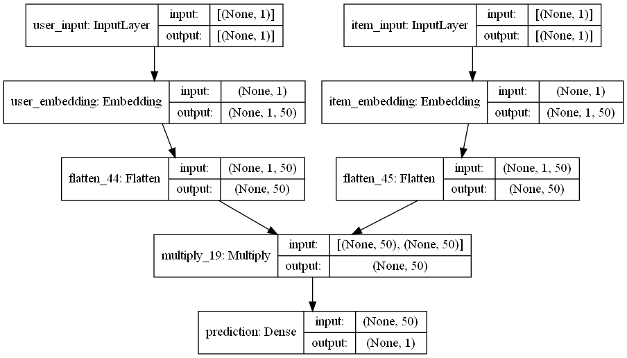

```python
plot_model(model, to_file='model_plot.png', show_shapes=True, show_layer_names=True)
```

```python
model.compile(optimizer=RMSprop(lr=0.001), metrics = ['accuracy', recall],  loss='binary_crossentropy')

# Train Model
early_stop = EarlyStopping(monitor='val_loss', min_delta=0.01, patience=3, verbose=1)
history = model.fit([X[:,0], X[:,1]], X[:,2], batch_size=150000, epochs=20, validation_split = 0.1, verbose=1, callbacks = [early_stop])
score = model.evaluate([testw['userId'].cat.codes.values, testw['movieId'].cat.codes.values], np.ones(testw.shape[0]), verbose=1, batch_size=100000)
print(f'Test Loss: {score[0]}   |   Test Recall: {score[1]}')
```

```
Epoch 00004: early stopping
Test Loss: 0.6857694387435913   |   Test Recall: 1.0
```

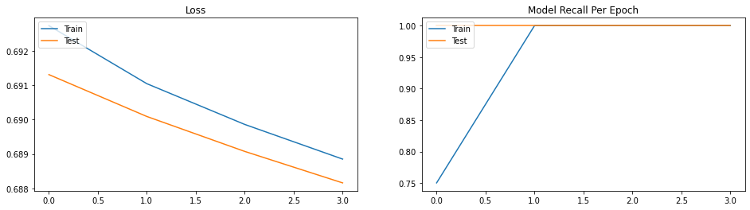

```python
fig, (axis1,axis2) = plt.subplots(1,2, figsize=(16,4))
axis1.plot(history.history['loss'])
axis1.plot(history.history['val_loss'])
axis1.set_title('Loss')
axis1.legend(['Train', 'Test'], loc='upper left')
axis2.plot(history.history['recall'])
axis2.plot(history.history['val_recall'])
axis2.set_title('Model Recall Per Epoch')
axis2.legend(['Train', 'Test'], loc='upper left')
plt.show()
```

```python
# compute MPR
# we implement per chunk to handle memory issues
user_index = testw['userId'].cat.codes.values
item_index = testw['movieId'].cat.codes.values
number_of_chunks = 10
chunks = np.array_split(np.arange(n_users), number_of_chunks)
res = []
prev_max = 0
for i,indexx in enumerate(chunks):
    print(f'Implementing chunk : {i+1}/{number_of_chunks}')
    cross_movieId = np.transpose([np.tile(np.arange(num_of_items), len(indexx)), np.repeat(indexx, len(np.arange(num_of_items)))])
    score = model.predict([cross_movieId[:,1], cross_movieId[:,0]], batch_size=50000, verbose=1).reshape(indexx.shape[0], num_of_items)
    score = (-score).argsort() / score.shape[1]
    sel = (user_index >= indexx.min()) & (user_index <= indexx.max())
    chunk_score = np.asarray(score[user_index[sel] - prev_max, item_index[sel]]).reshape(-1)
    res.append(chunk_score)
    prev_max = indexx.max() + 1
mpr_NCF = np.concatenate(res).sum()/len(testw)
print(f'NCF MPR: {mpr_NCF:.5f}')
rec_NCF = (np.concatenate(res) < 0.5).sum()/len(testw)
print(f'NCF Model Recall rate: {rec_NCF:.5f}')
```

```
Implementing chunk : 1/10
Implementing chunk : 2/10
Implementing chunk : 3/10
Implementing chunk : 4/10
Implementing chunk : 5/10
Implementing chunk : 6/10
Implementing chunk : 7/10
Implementing chunk : 8/10
Implementing chunk : 9/10
Implementing chunk : 10/10
NCF MPR: 0.49713
NCF Model Recall rate: 0.50613
```

```python
#Make movie predictions using the deep learning model
test_pred['score'] = list(np.concatenate(res))
#Select the top 5 movieIds to recommend to a user
testf = test_pred.sort_values(['score'],ascending=False).groupby('userId').head(5)
testf1 = testf.sort_values('userId')
testf1 = testf1[['userId', 'movieId']]
testf1.columns = ['userId', 'Recommended movieId']
testf1.head(10)
```

|  | userId | Recommended movieId |
| --- | --- | --- |
| 376830 | 0011a9baea | 111781 |
| 376794 | 0011a9baea | 80166 |
| 376754 | 0011a9baea | 8972 |
| 376759 | 0011a9baea | 34336 |
| 376719 | 0011a9baea | 4306 |
| 452570 | 00be0326d6 | 68237 |
| 452463 | 00be0326d6 | 2628 |
| 452458 | 00be0326d6 | 2396 |
| 452436 | 00be0326d6 | 1587 |
| 452550 | 00be0326d6 | 47610 |

#### Non-Negative Matrix Factorization

```python
def nmf_model(data, pred, model):
    # normalize to obtain the % importance to user
    scaled_df = data.multiply(1/data.sum(axis=1)).tocsr()
    W = model.fit_transform(scaled_df)
    H = model.components_

    # implement per chunk to handle memory issues
    user_index = pred['userId'].cat.codes.values
    item_index = pred['movieId'].cat.codes.values
    number_of_chunks = 30
    chunks = np.array_split(np.arange(W.shape[0]), number_of_chunks)
    res = []
    prev_max = 0
    for i,indexx in enumerate(chunks):
        print(f'Implementing chunk : {i+1}/{number_of_chunks}')
        score = (W[indexx].dot(H))
        score = (-score).argsort() / score.shape[1]
        sel = (user_index >= indexx.min()) & (user_index <= indexx.max())
        chunk_score = np.asarray(score[user_index[sel] - prev_max, item_index[sel]]).reshape(-1)
        res.append(chunk_score)
        prev_max = indexx.max() + 1
    return np.concatenate(res)

K = 2

# NMF
model = NMF(n_components = K, init = 'nndsvd', max_iter = 1000, tol = 0.1)
Recommendations1 = nmf_model(train_df, testw, model)
mpr_Non_Negative_Matrix_Factorization = Recommendations1.sum()/len(testw)
print(f'NMF MPR: {mpr_Non_Negative_Matrix_Factorization:.5f}')
rec_Non_Negative_Matrix_Factorization = (Recommendations1 < 0.5).sum()/len(testw)
print(f'Model Recall rate: {rec_Non_Negative_Matrix_Factorization:.5f}')
```

```
Implementing chunk : 1/30
Implementing chunk : 2/30
Implementing chunk : 3/30
Implementing chunk : 4/30
Implementing chunk : 5/30
Implementing chunk : 6/30
Implementing chunk : 7/30
Implementing chunk : 8/30
Implementing chunk : 9/30
Implementing chunk : 10/30
Implementing chunk : 11/30
Implementing chunk : 12/30
Implementing chunk : 13/30
Implementing chunk : 14/30
Implementing chunk : 15/30
Implementing chunk : 16/30
Implementing chunk : 17/30
Implementing chunk : 18/30
Implementing chunk : 19/30
Implementing chunk : 20/30
Implementing chunk : 21/30
Implementing chunk : 22/30
Implementing chunk : 23/30
Implementing chunk : 24/30
Implementing chunk : 25/30
Implementing chunk : 26/30
Implementing chunk : 27/30
Implementing chunk : 28/30
Implementing chunk : 29/30
Implementing chunk : 30/30
NMF MPR: 0.46395
Model Recall rate: 0.53426
```